# Task 5 - Data analysis

```r
library(tidyverse)
library(here)
```

# Read in cleaned data set

```r
rwa <- read_csv(here("clean_data/clean_data.csv"))
rwa
```

| id | rwa_score | testelapse | education | engnat | education_level | urban | gender | age | hand | familysize |
| --- | --- | --- | --- | --- | --- | --- | --- | --- | --- | --- |
| 1 | 1.35 | 129 | 3 | 1 | University degree | Suburban | Male | 18 | Right | 2 |
| 2 | 1.95 | 193 | 4 | 1 | Graduate degree | Rural | Male | 62 | Right | 3 |
| 3 | 4.70 | 238 | 1 | 2 | Less than high school | Suburban | Male | 16 | Right | 2 |
| 4 | 1.25 | 140 | 3 | 1 | University degree | Suburban | Female | 59 | Right | 3 |
| 5 | 2.60 | 455 | 2 | 1 | High School | Urban | Female | 49 | Both | 1 |
| 6 | 2.95 | 198 | 2 | 1 | High School | Urban | Male | 29 | Right | 3 |
| 7 | 1.20 | 515 | 2 | 1 | High School | Urban | Female | 22 | Right | 1 |
| 8 | 2.25 | 390 | 2 | 2 | High School | Urban | Male | 55 | Left | 8 |
| 9 | 1.05 | 269 | 2 | 1 | High School | Urban | Male | 24 | Right | 3 |
| 10 | 1.80 | 162 | 2 | 1 | High School | Suburban | Female | 18 | Right | 2 |

[output cut: 990 more lines]

```r
NA
```

Analysis questions:

# What’s the average RWA score for each gender?

```r
rwa %>%
  filter(!is.na(gender)) %>%
  group_by(gender) %>%
  summarise(avg_rwa_score = round(mean(rwa_score), 2)) %>%
  arrange(desc(avg_rwa_score))
```

| gender | avg_rwa_score |
| --- | --- |
| Male | 3.12 |
| Female | 2.47 |
| Other | 1.89 |

```r
NA
```

Average RWA scores for males, females and other are 3.12, 2.47 and 1.89, respectively.

# What’s the average RWA score for left handed people vs. right handed people?

```r
rwa %>%
  filter(hand == "Right" | hand == "Left") %>%
  group_by(hand) %>%
  summarise(avg_rwa_score = round(mean(rwa_score), 3))
```

| hand | avg_rwa_score |
| --- | --- |
| Left | 2.856 |
| Right | 2.857 |

```r
NA
```

# What’s the average family size for each type of childhood?

[Assumption] “Type” of childhood has been interpreted as which type of area did the person live in when they were a child, which relates to the column labelled “Urban”.

```r
rwa %>%
  filter(!is.na(urban)) %>%
  group_by(urban) %>%
  summarise(avg_family_size = round(mean(familysize), 2)) %>%
  arrange(desc(avg_family_size))
```

| urban | avg_family_size |
| --- | --- |
| Rural | 2.79 |
| Suburban | 2.62 |
| Urban | 2.50 |

```r
NA
```

The data shows that family size tended to be larger in rural areas (2.79), followed by suburban areas (2.62) and lastly urban areas (2.5).

# What’s the average time to take the test for each education level?

[Assumption] “testelapse” values taken to be in units of seconds.

```r
rwa %>%
  filter(!is.na(education_level)) %>%
  group_by(education_level) %>%
  summarise(avg_test_time = round(mean(testelapse), 0)) %>%
  arrange(avg_test_time)
```

| education_level | avg_test_time |
| --- | --- |
| Graduate degree | 330 |
| Less than high school | 380 |
| High School | 512 |
| University degree | 623 |

```r
NA
```

The results show that people with graduate degrees had the overall fastest time to complete the test, on average. This was followed by people who dropped out of high school, then high school graduates and lastly those with a university degree.

# Create a plot of results of question 4.

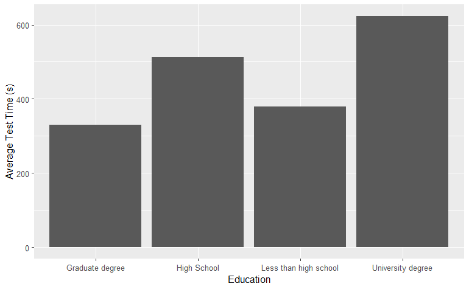

```r
rwa %>%
  filter(!is.na(education_level)) %>%
  group_by(education, education_level) %>%
  summarise(avg_test_time = round(mean(testelapse), 0)) %>%
  ggplot(aes(x = education_level, y = avg_test_time)) +
  geom_bar(stat = "identity") +
  labs(y= "Average Test Time (s)", x = "Education")
```

[don’t quite know how to put the education levels in ascending order]

# What’s the average RWA score for people aged:

Under 18 18 to 25 26 to 40 41 to 60 Over 60

```r
rwa %>%
  # categorise each numerical age value to an age range
  mutate(age_range = case_when(
    age < 18 ~ "Under 18",
    age <= 25 ~ "18 - 25",
    age <= 40 ~ "26 - 40",
    age <= 60 ~ "40 - 60",
    age > 60 ~ "Over 60"
  )) %>%
  # calcualte the average RWA score for each age range
  group_by(age_range) %>%
  summarise(avg_rwa_score = round(mean(rwa_score), 2)) %>%
  arrange(desc(avg_rwa_score))
```

| age_range | avg_rwa_score |
| --- | --- |
| Under 18 | 3.36 |
| 18 - 25 | 3.15 |
| 26 - 40 | 2.61 |
| 40 - 60 | 2.54 |
| Over 60 | 2.40 |

```r
NA
```

The output shows that the average RWA score decreases with age. Under 18s have the highest score with 3.36 followed by the 18 - 25, 26 - 40, 40 - 60 and over 60s category with average RWA scores of 3.15, 2.61, 2.54 and 2.40, respectively.